# Literature Reviews:

Together we can learn to love tolerate them

Rachel Franklin

Newcastle University

2024-05-10

## First things first

Why do we do literature reviews? Who are they for and what purpose do they serve?

1. We do them because they’re expected
2. We do them for ourselves
3. We do them for others in the field—they’re an integral component of a research road map
4. *All of the above*

[figure not shown]

source: xkcd.com/2281/

## Research Road Map: The Elements of a Paper

- **Introduction**
  - Where you convince yourself and others of the what, why, and how of your research
  - This is three parts motivation, justification, and promotion
- **Literature Review/Background**
- **Data and Methods**—These elements are like a recipe; can someone cook the same research meal from your description?
- **Analysis and Discussion**—Not only what you did (the analysis), but what you found!
- **Conclusions**—Brief synopsis of what you’ve done, but mostly main takeaways (main findings, contribution to the literature, policy relevance, caveats, future research)

## There’s no one right way to do a literature review

- The more you read and the more you practice, the more you see there are lots of ways to successfully write a scientific work
- The internet is useful for all things academic!
  - Read and discard what doesn’t apply to you
- I find it most helpful to think of the literature review as a process, one that you undergo for your own understanding of a topic
- Once that’s settled in your mind, the writing and the structure will come more easily

## What purpose does it serve?

- A literature review synthesizes and assesses *what* we know about a topic and *how* we know it
- And also sketches out a place for the research you are about to describe
  - This may not be an obvious “gap”!!
- Usually outlines the origin of the topic (e.g., seminal papers), reinforced with what others have done
  - May be variations on the general theme, replications in different places or with different variables or models, or exploring different functional mechanisms
- Don’t forget the *how*: data, methods, variables

## Some questions we can ask ourselves

- What questions are asked on this topic?
- What do we know?
- The mechanisms by which a phenomenon is hypothesized to operate and what previous research has shown
- How are questions asked/answered?
  - Methods
  - Variables
  - Data

Are there disputes or equivocal approaches? How will you fit into these debates?

## Maybe you’re thinking: Why do I have to do this?

- What we find in our research is dependent on how we framed the question in the first place
  - For **ourselves**, we want to lay out our assumptions, context, and expectations
  - For **others**, we want to help them understand where we’re coming from and why we do what we do (research question, but also methods and data!)
- Knowing what has been found in previous research will help you to place your findings into a larger context later in the paper/thesis
  - e.g., “similar to so-and-so, we also find that X has a strong positive effect on Y”
- To get ideas for model specifications, variables, possible challenges that may arise and how to avert them, interpretation of results, etc
- It is *not* about establishing that no one has done what you’re doing ever before in history
- In fact, life is much easier if you can link to some related research.

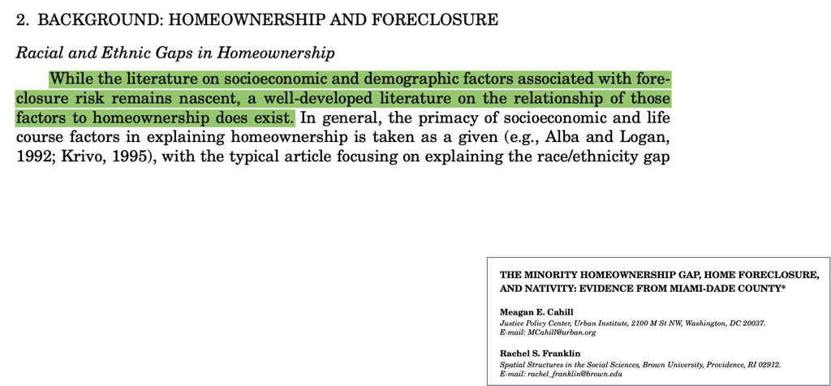

[figure not shown]

## How to get started (some ideas)

- You’re going to need to read
- A “snowball” approach can be easiest
  - Start with the one or two papers that you know are relevant and useful
  - The ones you know you would cite
  - Look at their references and read those (relevant) papers
- Google + Google Scholar
  - This is not a quick approach! It requires time and skimming lots of papers until you find the good stuff!
- Start to identify the main themes in your topic
  - Don’t organize around paper; organize around topic or theme!

## Last words of advice

- When you take notes on a paper, keep track of what you valued it for
  - Foundational literature? For their methodological approach? For the niche/gap in the literature they identify?
- When you find a really useful paper, have a look at their references!
- Your literature review should not read like a laundry list of citations.
- Have a structure in mind after you’re done reading and before you sit down to write
- It’s ok to cite selectively, but be aware of who you’re including/excluding!
- What if you can’t find any related research? You’ll need to be creative about establishing a broader context for your work
- Keep in mind who your community of scholars is: what literatures will they be expecting you to draw from?

[figure not shown]

source: https://xkcd.com/2268/